# houses2.R

jevon

2023-06-02

# Housing Prices Project (part 2)

In the previous file, we worked on modeling the relationship between `price` and `area`. In this file, we’ll work on building a model with all the variables in the dataset, but with special attention to the variable `bedrooms`. The interesting thing with `bedrooms` is that it’s a variable that appears to be very important in the simple regression context, but when you add all the other variables in the dataset, it loses a lot of statistical significance and you may wonder whether it even belongs in the full model at all. Multicollinearity is the culprit: `bedrooms` is highly correlated with several of the other variables and as a result, its slope estimate will not be biased, but it will be measured imprecisely (large standard errors). At the end of this file we’ll think about some possible fixes.

```r
library(tidyverse)
houses <- read_csv("https://raw.githubusercontent.com/cobriant/EC320Lab9/main/Housing.csv")
```

# 1. Simple Regression

First, visualize the relationship between `log(price)` amd `bedrooms` with a scatterplot (use `geom_jitter` since bedrooms is discrete). Then fit the model $log(price) = \beta_0 + \beta_1 bedrooms + u$ and interpret the slope coefficient’s estimate and statistical significance. You should find that `bedrooms` seems to be an important factor in house price.

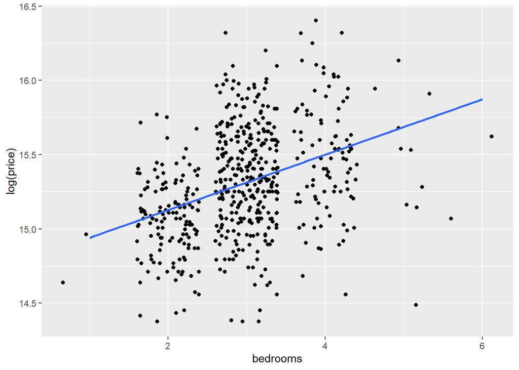

```r
houses %>%
  ggplot(aes(x = bedrooms, log(price))) +
  geom_jitter() +
  geom_smooth(method = lm, se = FALSE)
```

```r
houses %>%
  lm(log(price) ~ bedrooms, data = .) %>%
  broom::tidy()
```

```
## # A tibble: 2 × 5
##   term        estimate std.error statistic  p.value
##   <chr>          <dbl>     <dbl>     <dbl>    <dbl>
## 1 (Intercept)   14.8      0.0614    240.   0
## 2 bedrooms       0.187    0.0201      9.28 4.01e-19
```

this has a tiny p value and so is significent there is an increse in price by .18 for each bedroom added # 2. Multiple Regression

Here I fit a full model of `log(price)`. Notice in the lm formula, I can use a `.` to indicate I want to include all the other variables in the dataset.

Interpret the slope coefficient on `bedrooms` and its statistical significance. You should find that, compared to the simple regression, when we include the other variables in the dataset, `bedrooms` starts to lose significance.

```r
houses %>%
  lm(log(price) ~ ., data = .) %>%
  broom::tidy()
```

```
## # A tibble: 14 × 5
##    term                             estimate  std.error statistic  p.value
##    <chr>                               <dbl>      <dbl>     <dbl>    <dbl>
##  1 (Intercept)                    14.4       0.0512       281.    0
##  2 area                            0.0000495 0.00000470    10.5   1.14e-23
##  3 bedrooms                        0.0295    0.0141         2.10  3.64e- 2
##  4 bathrooms                       0.163     0.0200         8.16  2.47e-15
##  5 stories                         0.0901    0.0124         7.26  1.41e-12
##  6 mainroadyes                     0.117     0.0275         4.27  2.34e- 5
##  7 guestroomyes                    0.0698    0.0255         2.74  6.39e- 3
##  8 basementyes                     0.0893    0.0213         4.18  3.34e- 5
##  9 hotwaterheatingyes              0.163     0.0432         3.78  1.72e- 4
## 10 airconditioningyes              0.175     0.0210         8.34  6.62e-16
## 11 parking                         0.0448    0.0113         3.95  8.77e- 5
## 12 prefareayes                     0.127     0.0224         5.66  2.46e- 8
## 13 furnishingstatussemi-furnished  0.0180    0.0226         0.796 4.26e- 1
## 14 furnishingstatusunfurnished    -0.110     0.0244        -4.50  8.36e- 6
```

for each increese in bedrooms there is a almost 3% incresss in price # 3. Multicollinearity

The reason why `bedrooms` starts to lose significance when we add more variables is that `bedrooms` is highly correlated with many of the other explanatory variables. Show that this is true by finishing the code below to coerce each factor variable to be numeric so that we can calculate the correlation matrix. What are the 3 variables `bedrooms` is most correlated with? mainroad, hotwaterheating, prefarea

```r
houses %>%
  mutate(
    mainroad = if_else(mainroad == "yes", 1, 0),
    guestroom = if_else(guestroom == "yes", 1, 0),
    basement = if_else(basement == "yes", 1, 0),
    hotwaterheating = if_else(hotwaterheating == "yes", 1, 0),
    airconditioning = if_else(airconditioning == "yes", 1, 0),
    prefarea = if_else(prefarea == "yes", 1, 0),
    furnishingstatus = case_when(
      furnishingstatus == "furnished" ~ 1,
      furnishingstatus == "semi-furnished" ~ 0.5,
      furnishingstatus == "unfurnished" ~ 0
    )
  ) %>%
  cor() %>%
  view()
```

# 4. Frisch-Waugh-Lovell Theorem

Multiple regression lets us describe the relationship between two variables, *all others held constant*. We can use the FWL theorem to visualize that relationship, and here’s how: Since we want to hold everything else constant, we’ll clean `bedrooms` of its correlations with the other explanatory variables by using `mutate` to transform `bedrooms` to be the residual of this regression: `bedrooms ~ area + bathrooms + stories + mainroad + ...`: everything except for price. (Hint: you might want to use the `.` trick in the regression above paired with `select(-price)` to drop the price variable). Do the same thing for `price`: clean `log(price)` of its correlations with all the other explanatory variables except for `bedrooms`. Then plot those bedroom_residuals on the x-axis against the log_price_residuals on the y-axis. The slope of the line of best fit will be the same as the slope coefficient in the multiple regression from question 2. This lets you see, all other variables held constant, whether or not `bedrooms` seems to have a strong linear relationship with `log(price)`.

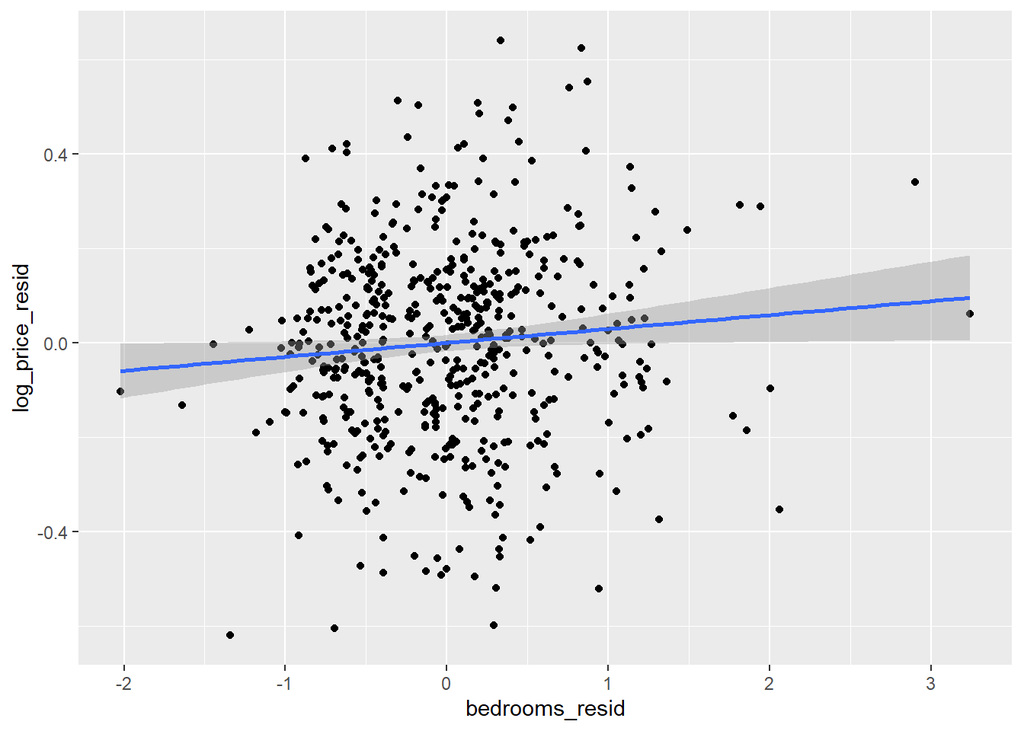

```r
houses %>%
  mutate(
    bedrooms_resid = residuals(lm(bedrooms ~ . - price, data = .)),
    log_price_resid = residuals(lm(log(price) ~ . - bedrooms, data = .))
  ) %>%
  ggplot(aes(x = bedrooms_resid, y = log_price_resid)) +
  geom_point() +
  geom_smooth(method = lm)
```

# 5. Conclusion

We’ve shown that `bedrooms` suffers from multicollinearity because it is highly correlated with other explanatory variables in the regression. As a result, the estimator for its effect on price will be unbiased, but imprecise (standard errors are large and the estimate may be statistically insignificant when in reality it’s likely an important variable in the data generating process).

There are a couple of potential fixes for multicollinearity: 1. We can increase the precision of all of the estimates by: Adding more data to increase the sample size, or Including more explanatory variables to soak up more of the variation in u 2. Combine the correlated variables into an overall index (example: a price index combines prices of all kinds of consumer goods and services) 3. Drop some of the correlated variables if they have insignificant coefficients. The problem here is that this may cause omitted variable bias depending on what those variables are.

A question for you: Which of these fixes, if any, would be possible? Why? the third solution seems the best as it is easyer to remove data then gather more